# project

**Import Data**

```python
import pandas as pd
import numpy as np
import seaborn as sns
import matplotlib.pyplot as plt
sns.set_theme()
```

```python
rental = pd.read_csv("./Rental_Properties.csv")
```

**Data Description**

```python
rental.describe()
```

|  | pool | dishwasher | washer-dryer | ac | parking | zip | price | num_beds | num_baths | sqft | Population | PopulationDensity | security_deposit |
| --- | --- | --- | --- | --- | --- | --- | --- | --- | --- | --- | --- | --- | --- |
| count | 41733.0 | 94610.0 | 276747.000000 | 276749.000000 | 276748.000000 | 276757.000000 | 271552.000000 | 254871.000000 | 276757.000000 | 276757.000000 | 276757.000000 | 276757.000000 | 276752.000000 |
| mean | 1.0 | 1.0 | 0.314937 | 0.172716 | 0.140413 | 56829.354770 | 1860.328961 | 2.103668 | 1.535356 | 784.535990 | 33453.696763 | 9059.428351 | 1072.839268 |
| std | 0.0 | 0.0 | 0.464492 | 0.378002 | 0.347416 | 29330.719215 | 1990.950453 | 4.745117 | 3.712672 | 1325.696047 | 18764.826974 | 16007.898259 | 1857.331634 |
| min | 1.0 | 1.0 | 0.000000 | 0.000000 | 0.000000 | 1002.000000 | 0.000000 | -3.000000 | -2.000000 | 0.000000 | 0.000000 | 0.000000 | 0.000000 |
| 25% | 1.0 | 1.0 | 0.000000 | 0.000000 | 0.000000 | 32221.000000 | 1055.000000 | 1.000000 | 1.000000 | 0.000000 | 20853.000000 | 1081.000000 | 0.000000 |
| 50% | 1.0 | 1.0 | 0.000000 | 0.000000 | 0.000000 | 60625.000000 | 1550.000000 | 2.000000 | 1.000000 | 750.000000 | 31178.000000 | 3784.000000 | 600.000000 |
| 75% | 1.0 | 1.0 | 1.000000 | 0.000000 | 0.000000 | 78852.000000 | 2175.000000 | 3.000000 | 2.000000 | 1150.000000 | 44489.000000 | 10462.000000 | 1550.000000 |
| max | 1.0 | 1.0 | 1.000000 | 1.000000 | 1.000000 | 99901.000000 | 199999.000000 | 1750.000000 | 1900.000000 | 509230.000000 | 115538.000000 | 145764.000000 | 115000.000000 |

**Data Cleaning**

```python
cleaned_data = rental[(rental.price != 0) & (rental.num_baths >= 0)
                    & (rental.num_beds > 0) & (rental.sqft > 0) & (rental.PopulationDensity > 0) & (rental.ac)].dropna().copy()
```

**1. Draw the boxplot to the price and the square feet to observe any anomaly data points and investigate its distribution.**

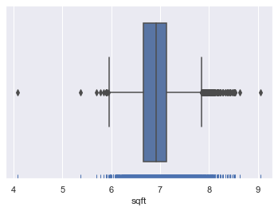

```python
sns.boxplot(x=np.log(cleaned_data['sqft']))
sns.rugplot(x=np.log(cleaned_data['sqft']))
plt.savefig('sqft.png')
```

**Comment:** under the log scale, there are still many outliers in the price.

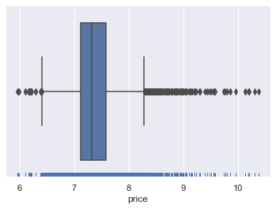

```python
sns.boxplot(x=np.log(cleaned_data['price']))
sns.rugplot(x=np.log(cleaned_data['price']))
plt.savefig('price.png')
```

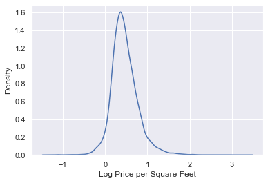

```python
sns.kdeplot(x=np.log(cleaned_data['price']/cleaned_data['sqft']))
plt.xlabel("Log Price per Square Feet")
plt.savefig('price_per_sqft.png')
```

```python
cleaned_data['log_sqft'] = np.log(cleaned_data['sqft'])
cleaned_data['log_price'] = np.log(cleaned_data['price'])
```

**2. Use a regplot to show the relationship between rental price and the square feet of the house and differentiate the data from different house types**

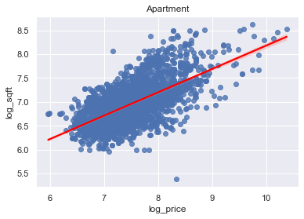

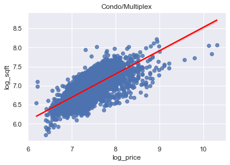

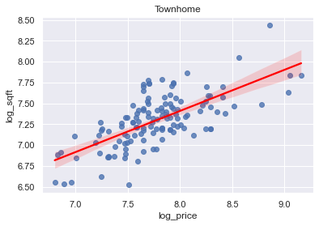

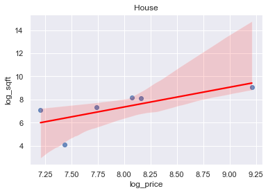

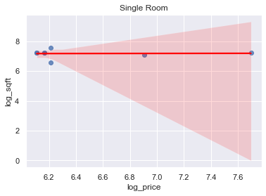

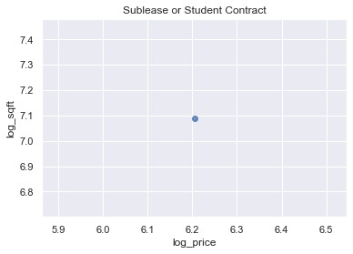

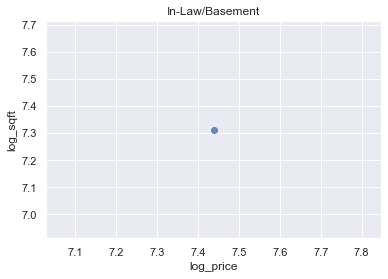

```python
for house_type in cleaned_data.house_type.unique():
    plt.figure()
    sns.regplot(data=cleaned_data[cleaned_data.house_type == house_type], x='log_price', y='log_sqft',
                  line_kws={"color": "red"})
    plt.title(house_type)
```

We can find the more clear relationship in the first three figures.

```python
from sklearn.preprocessing import OneHotEncoder

ohe = OneHotEncoder(sparse=False)
res_ohe = ohe.fit_transform(cleaned_data[['house_type']].values)
ohe_df = pd.DataFrame(res_ohe, columns=ohe.categories_[0]).astype(int)
ohe_cleaned_data = cleaned_data.join(ohe_df).copy()
```

**3. Draw the mean and the variance of the rental price per square feet in each state.**

```python
ohe_cleaned_data['log_price_per_sqft'] = ohe_cleaned_data['log_price'] - ohe_cleaned_data['log_sqft']
log_price_per_state = ohe_cleaned_data[['log_price_per_sqft', 'state']].groupby('state', as_index=False).agg(['mean', 'std'])
print(log_price_per_state)
```

```
      log_price_per_sqft
                    mean       std
state
AL              0.068290  0.255567
AR              0.281397  0.241469
AZ              0.411957  0.193865
CA              0.861286  0.316293
CO              0.492050  0.307172
CT              0.965926  0.031142
DC              0.977310  0.698783
DE              0.095310       NaN
FL              0.750726  0.445421
GA              0.314460  0.382812
HI              0.910512  0.463011
IA             -0.125784  0.081173
IL              0.977761  0.307873
IN              0.071079  0.207233
KS             -0.072385  0.050884
KY              0.169106  0.041499
LA              0.078144  0.248065
MA              1.394963  0.441735
MD              0.267819  0.120602
MI              0.200699  0.553758
MN              0.181203  0.198528
MO              0.068705  0.309396
MS              0.111946  0.208184
NC              0.078576  0.244881
ND              0.078353  0.247984
NE             -0.103016  0.060335
NJ              1.262391  0.298616
NM              0.183983  0.215046
NV              0.411929  0.213680
NY              1.324281  0.867587
OH              0.067825  0.269319
OK              0.151898  0.206392
OR              1.210820  1.430389
PA              0.157511  0.035088
SC              0.160854  0.357686
SD              0.263966       NaN
TN              0.458115  0.555596
TX              0.436796  0.235141
UT              0.317709  0.284172
VA             -0.015439  0.664620
WA              0.947667  0.424465
WI             -0.087281  0.147657
```

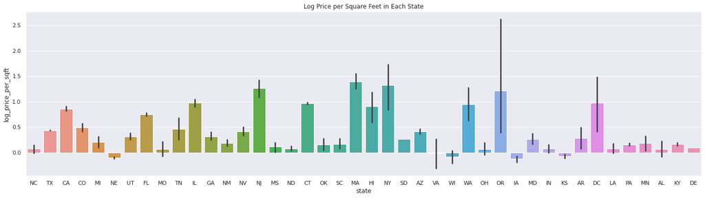

```python
sns.set(rc = {'figure.figsize':(24, 6)})
sns.barplot(data=ohe_cleaned_data, x='state', y='log_price_per_sqft')
plt.title('Log Price per Square Feet in Each State')
plt.savefig("state.png")
sns.reset_orig()
```

We can clearly see the log price per sqft of different states varies.

**4. Draw the heatmap of the pearson coefficients of each two columns in the dataset**

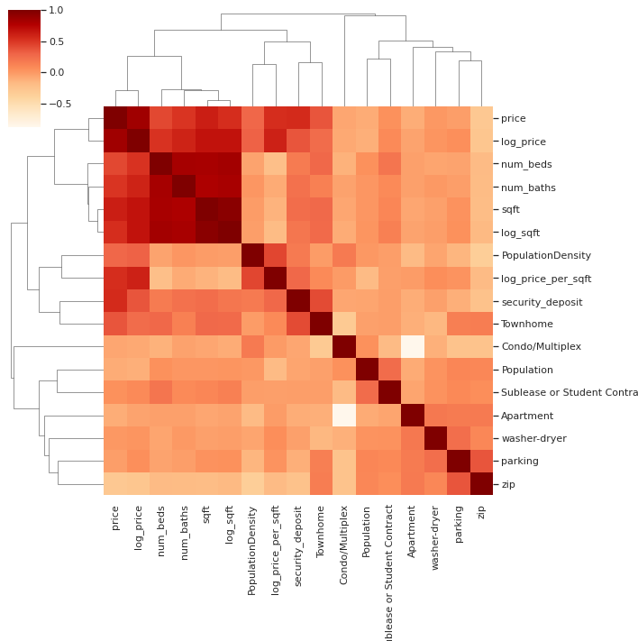

```python
price_corr = ohe_cleaned_data.select_dtypes('number').corr().dropna(axis=0, how='all').dropna(axis=1, how='all')
sns.set(rc = {'figure.figsize':(12, 12)})
sns.clustermap(price_corr, cmap=plt.cm.OrRd)
plt.savefig("heatmap.png")
sns.reset_orig()
```

```python
price_corr[['log_price', 'price']]
```

|  | log_price | price |
| --- | --- | --- |
| washer-dryer | 0.023444 | 0.003122 |
| parking | 0.052787 | -0.025666 |
| zip | -0.275058 | -0.294503 |
| price | 0.846336 | 1.000000 |
| num_beds | 0.517330 | 0.422224 |
| num_baths | 0.595390 | 0.509956 |
| sqft | 0.672253 | 0.615791 |
| Population | -0.113112 | -0.099654 |
| PopulationDensity | 0.306704 | 0.286839 |
| security_deposit | 0.365116 | 0.555509 |
| log_sqft | 0.676089 | 0.543666 |
| log_price | 1.000000 | 0.846336 |
| Apartment | -0.050245 | -0.105082 |
| Condo/Multiplex | -0.080005 | -0.064573 |
| Sublease or Student Contract | 0.077212 | 0.043839 |
| Townhome | 0.258611 | 0.364315 |
| log_price_per_sqft | 0.598632 | 0.537662 |

```python
price_corr['log_price_per_sqft'].sort_values(ascending=False)
```

```
log_price_per_sqft              1.000000
log_price                       0.598632
price                           0.537662
PopulationDensity               0.433854
security_deposit                0.273862
Townhome                        0.080488
washer-dryer                    0.056203
parking                         0.024735
Condo/Multiplex                -0.010482
Apartment                      -0.016193
Sublease or Student Contract   -0.032718
num_baths                      -0.092651
sqft                           -0.131420
Population                     -0.174652
zip                            -0.178087
log_sqft                       -0.185482
num_beds                       -0.217095
Name: log_price_per_sqft, dtype: float64
```

**5. draw a violin plot to show the relationship between rental price and the number of bedrooms.**

```python
sns.set_theme()
```

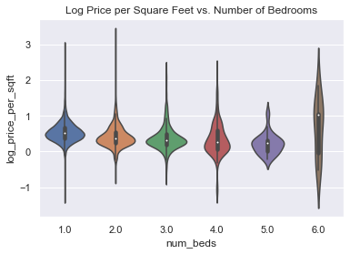

```python
sns.violinplot(data=ohe_cleaned_data, x='num_beds', y='log_price_per_sqft')
plt.title("Log Price per Square Feet vs. Number of Bedrooms")
plt.show()
```

```python
log_price_beds = ohe_cleaned_data[['log_price_per_sqft', 'num_beds']].groupby('num_beds').agg(['mean', 'std'])
print(log_price_beds)
```

```
         log_price_per_sqft
                       mean       std
num_beds
1.0                0.541359  0.270110
2.0                0.414056  0.306414
3.0                0.375056  0.339288
4.0                0.338021  0.457231
5.0                0.216270  0.286877
6.0                0.666143  0.804612
```

**6. Draw the distribution of the rental price per square feet for different population density with violinplot**

```python
idx = np.where(ohe_cleaned_data.PopulationDensity > 0)[0]
bins = np.quantile(ohe_cleaned_data.iloc[idx]['PopulationDensity'], q=[0, 1/3, 2/3, 1])
labels = ['low', 'median', 'high']
ohe_cleaned_data['bin_population'] = pd.cut(x=ohe_cleaned_data.iloc[idx]['PopulationDensity'], bins=bins, labels=labels)
```

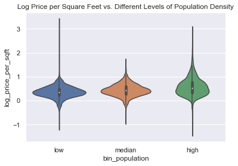

```python
sns.violinplot(data=ohe_cleaned_data.iloc[idx], y='log_price_per_sqft', x='bin_population')
plt.title("Log Price per Square Feet vs. Different Levels of Population Density")
plt.savefig('population.png')
```

**7. cluster the data with square feet, baths, bedrooms, population density**

```python
from sklearn.decomposition import PCA
from sklearn.preprocessing import StandardScaler
from sklearn.metrics import silhouette_score
from sklearn.cluster import KMeans
```

```python
feats_ = ["log_sqft", "num_beds", "num_baths", "PopulationDensity"]
X = ohe_cleaned_data[feats_]
scalar = StandardScaler()
data = scalar.fit_transform(X)
```

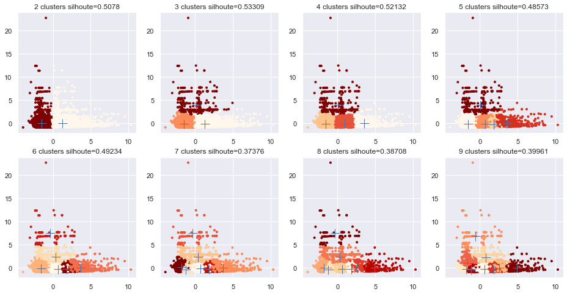

```python
pca = PCA(n_components=2).fit(data)
data2d = pca.transform(data)

plt.figure(figsize=(16, 8))
scores, n_clusters, preds = [], [], []
for i in range(2, 10):
    kmean = KMeans(n_clusters = i, random_state=22).fit(data)
    scores.append(kmean.score(data))
    n_clusters.append(i)
    pred = kmean.predict(data)
    preds.append(pred)
    plt.subplot(2, 4, i - 1)
    plt.title(f"{i} clusters silhoute={np.round(silhouette_score(data, pred), decimals=5)}")
    plt.scatter(x=data2d[:, 0], y=data2d[:, 1], c=pred, cmap=plt.cm.OrRd, marker = '.')

    centroids = kmean.cluster_centers_
    centroids2d = pca.transform(centroids)
    plt.plot(centroids2d[:, 0], centroids2d[:, 1], 'b+', markersize=15)
plt.savefig("sihoute.png")
```

```python
a, b = np.unique(preds[1], return_counts=True)
ratio = (b / b.sum()).cumsum()
ratio = [0] + list(ratio)
ratio
```

```
[0, 0.5158586688578471, 0.9654067378800328, 1.0]
```

**8. extract the vector representation**

```python
target_ = "log_price_per_sqft"
y = ohe_cleaned_data[target_]
```

```python
U, S, Vt = np.linalg.svd(data, full_matrices=False)
```

```python
num_sv = np.arange(1, S.size+1)
cum_var_explained = [np.sum(np.square(S[0:n])) / np.sum(np.square(S)) for n in num_sv]
cum_var_explained
```

```
[0.6614144375493269, 0.9117611479038991, 0.9587414028036286, 1.0]
```

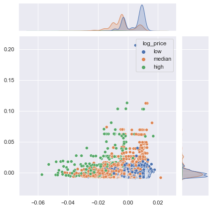

```python
ux, uy = U[:, 0], U[:, 1]

data = ohe_cleaned_data['log_price']
k = 3
q = ["low", "median", "high"]
bins = np.quantile(data, q=ratio)
hue = pd.cut(x=data, bins=bins, labels=q)

sns.jointplot(x=ux, y=uy, hue=hue)
plt.savefig("svd.png")
```

We can see that with the two main principal components, we can rougly separate the data.

**9. prediction**

**Baseline**

```python
data = np.exp(ohe_cleaned_data.log_price_per_sqft)
mean_err = ((data - data.mean())**2).mean()
print(mean_err)
```

```
0.4865885510835116
```

```python
from sklearn.tree import DecisionTreeRegressor
from sklearn.model_selection import cross_validate
from sklearn.metrics import mean_squared_error
```

```python
def err_func(regressor, x, y):
    y_pred = np.exp(regressor.predict(x))
    y_true = np.exp(y)
    return mean_squared_error(y_true, y_pred)
```

```python
feats_ = ["log_sqft", "num_beds", "num_baths", "PopulationDensity"]
X = ohe_cleaned_data[feats_]

scalar = StandardScaler()
data = scalar.fit_transform(X)
```

```python
regressor = DecisionTreeRegressor(max_depth=3, min_samples_leaf=0.01)
scores = cross_validate(
    estimator=regressor,
    X=data, y=y, cv=5,
    scoring=err_func,
    return_train_score=True,
    return_estimator=True
)
print(pd.DataFrame(scores))
```

```
   fit_time  score_time                                          estimator  \
0  0.007998    0.000999  DecisionTreeRegressor(max_depth=3, min_samples...
1  0.007994    0.001003  DecisionTreeRegressor(max_depth=3, min_samples...
2  0.007002    0.000999  DecisionTreeRegressor(max_depth=3, min_samples...
3  0.007003    0.001149  DecisionTreeRegressor(max_depth=3, min_samples...
4  0.007031    0.001002  DecisionTreeRegressor(max_depth=3, min_samples...

   test_score  train_score
0    0.843284     0.282994
1    0.460203     0.362394
2    0.148194     0.430659
3    0.255631     0.405302
4    0.254045     0.405969
```

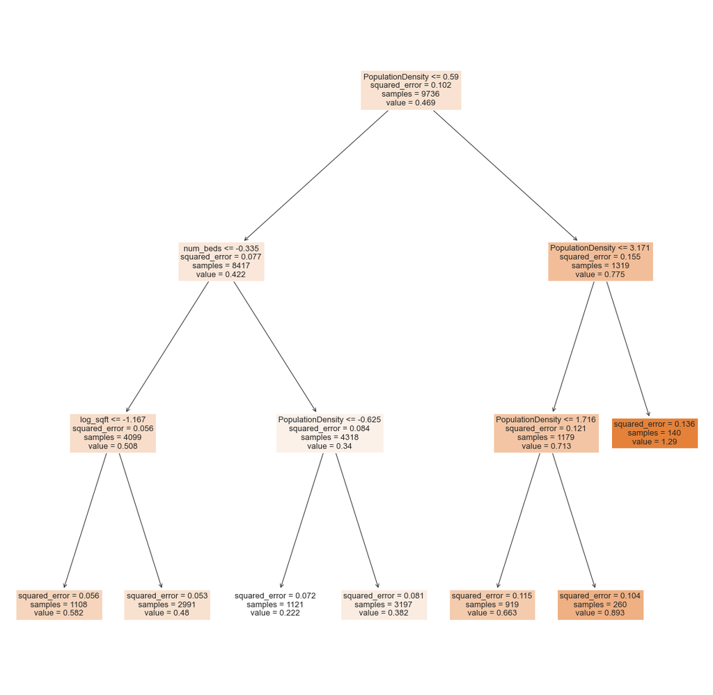

```python
from sklearn import tree

regressor = scores['estimator'][-1]
fig = plt.figure(figsize=(20,20))
_ = tree.plot_tree(regressor,
                   feature_names=feats_,
                   class_names=target_,
                   filled=True)
plt.savefig("tree.png")
```

```python
scores['test_score'].mean(), scores['train_score'].mean()
```

```
(0.3922714118451818, 0.3774637005239975)
```